# pract_1_YevgeniiYatsentiuk

## Практична робота № 1 Асимптотична складність алгоритмів. 𝐎-нотація

## Мета: набути практичних навичок у розв’язанні задач на оцінку асимптотичної складності алгоритмів у 𝐎.

### Виконав: Яцентюк Євгеній, група: КІ-24-1

**[GitHub](https://github.com/kefir4ikk)**

Вибір варіанта Згідно з правилом $n, n+5$, де $n=23$ (номер у списку):

1. Задача 1: $23 - 15 = 8$
2. Задача 2: $23 + 5 = 28 \rightarrow 28 - 15 = 13$.

## Завдання 1 (№ 8 у списку)

**Умова:** Довести, що $f(n) = 2n^2 + 10n + 3 = O(n^2)$.

**Розв'язання:** Згідно з визначенням, $f(n) = O(g(n))$, якщо існують константи $c > 0$ та $n_0 \ge 1$, такі що $f(n) \le c \cdot g(n)$ для всіх $n \ge n_0$.

Оцінимо функцію зверху для $n \ge 1$: $$2n^2 + 10n + 3 \le 2n^2 + 10n^2 + 3n^2$$ (ми замінили $n$ та $1$ на $n^2$, оскільки при $n \ge 1$ це збільшує або залишає значення незмінним).

$$2n^2 + 10n^2 + 3n^2 = 15n^2$$

Отже: $$2n^2 + 10n + 3 \le 15n^2$$

**Результат:** Ми знайшли константи:

- $c = 15$
- $n_0 = 1$

Оскільки нерівність виконується, твердження доведено.

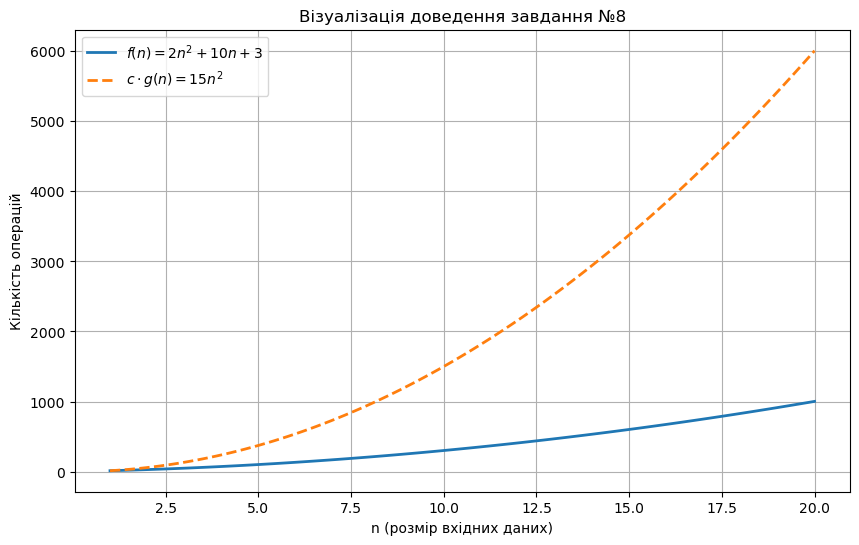

```python
import matplotlib.pyplot as plt
import numpy as np

# Діапазон значень n
n = np.linspace(1, 20, 100)

# Функції
f_n = 2 * n**2 + 10 * n + 3
g_n_c = 15 * n**2  # c * g(n), де c = 15

# Побудова графіка
plt.figure(figsize=(10, 6))
plt.plot(n, f_n, label=r'$f(n) = 2n^2 + 10n + 3$', linewidth=2)
plt.plot(n, g_n_c, label=r'$c \cdot g(n) = 15n^2$', linestyle='--', linewidth=2)

plt.title('Візуалізація доведення завдання №8')
plt.xlabel('n (розмір вхідних даних)')
plt.ylabel('Кількість операцій')
plt.legend()
plt.grid(True)
plt.show()
```

## Завдання 2 (№ 13 у списку)

**Умова:** Задано функції $f(n) = 100n^3 + 8$ та $g(n) = n^3$. Доведіть, що $f(n) = O(g(n))$.

**Розв'язання:** Потрібно знайти $c$ та $n_0$, щоб виконувалась нерівність: $$100n^3 + 8 \le c \cdot n^3$$

Оцінимо вираз для $n \ge 1$:

1. Член $100n^3$ залишаємо без змін.
2. Константу $8$ замінюємо на $8n^3$ (оскільки $1 \le n^3$ при $n \ge 1$, то $8 \le 8n^3$).

Отримуємо: $$100n^3 + 8 \le 100n^3 + 8n^3 = 108n^3$$

Таким чином, для $c = 108$ та $n_0 = 1$ умова $f(n) \le c \cdot g(n)$ виконується.

**Результат:** Доведено, що $f(n) = O(n^3)$ з константою $c=108$.

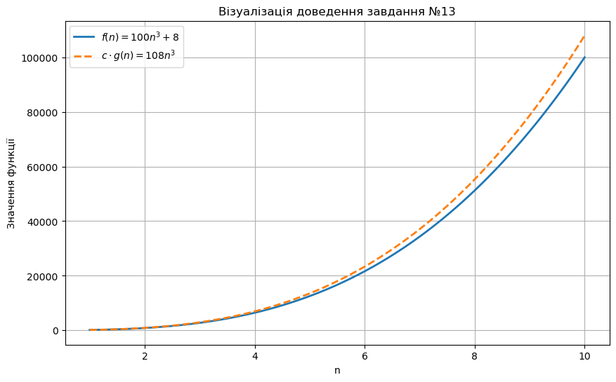

```python
# Діапазон значень n
n = np.linspace(1, 10, 100)

# Функції
f_n_2 = 100 * n**3 + 8
g_n_c_2 = 108 * n**3  # c * g(n), де c = 108

# Побудова графіка
plt.figure(figsize=(10, 6))
plt.plot(n, f_n_2, label=r'$f(n) = 100n^3 + 8$', linewidth=2)
plt.plot(n, g_n_c_2, label=r'$c \cdot g(n) = 108n^3$', linestyle='--', linewidth=2)

plt.title('Візуалізація доведення завдання №13')
plt.xlabel('n')
plt.ylabel('Значення функції')
plt.legend()
plt.grid(True)
plt.show()
```

## Відповіді на контрольні питання

**1. Що таке асимптотична складність алгоритму?**

Асимптотична складність — це оцінка ефективності алгоритму, яка описує, як швидко зростає функція $f(n)$ (кількість часу або простору) зі збільшенням розміру вхідних даних $n$. При цьому нас цікавить не точне значення для певного $n$, а швидкість зростання функції (її порядок) при прагненні $n$ до нескінченності.

**2. Яким чином визначається $O$-нотація і яка її сутність?**

- **Визначення:** $f(n) = O(g(n))$, якщо існують такі константи $c > 0$ та $n_0$, що для всіх $n \ge n_0$ виконується нерівність $f(n) \le c \cdot g(n)$.
- **Сутність:** Вона описує асимптотичну **верхню межу** часу виконання. Це означає, що функція $f(n)$ росте «не швидше», ніж $g(n)$ (або щонайбільше так само швидко). Мета введення $n_0$ — ігнорувати поведінку функції на малих значеннях $n$.

**3. Які основні правила використання $O$-нотації при аналізі алгоритмів?**

Існують два основні правила спрощення:

1. **Правило домінування (суми):** Якщо функція представлена сумою кількох членів, то порядок визначає той член, який росте найшвидше. Він починає домінувати при $n \to \infty$, роблячи внесок інших незначним.
2. **Правило констант:** Константи (фактори), які не залежать від аргументу функції, можна опускати. Наприклад, замість $O(4n^3)$ пишемо $O(n^3)$.

**4. Що означають вирази $O(1)$, $O(n)$, $O(n^2)$ в контексті асимптотичної складності?**

Ці вирази позначають класи функцій за швидкістю їх зростання:

- $O(1)$ — константна складність (найменша в ланцюжку, швидкість не залежить від $n$).
- $O(n)$ — лінійна складність (росте швидше за $\sqrt{n}$, але повільніше за $n \log n$).
- $O(n^2)$ — квадратична складність (росте швидше за $n \log n$, але повільніше за $n^3$).

**5. Яким чином визначити асимптотичну складність алгоритму за його кодом або математичним виразом?**

Для визначення складності потрібно максимально спростити вираз функції $f(n)$:

1. Записати функцію $f(n)$, що описує кількість кроків алгоритму.
2. Знайти член виразу з найвищим степенем (найшвидшим темпом зростання).
3. Відкинути всі константні множники біля цього члена.
   - *Приклад:* Для $f(n) = 7n^4 + 5n^3 + 3$ домінуючим є $n^4$, а константу $7$ відкидаємо, тому складність $O(n^4)$.